# Homework 1 (CSC 495)

Brian Craft

Winter 2017

## Some visualizations of the Dining data

```r
library(knitr)
setwd("~/Documents/Craft-Repo/social_networks/homework_1")

read_chunk("hwk1.R")
knitr::opts_chunk$set(echo = TRUE)
```

### Load packages

```r
# Load packages

library("ggplot2")
# Must load other packages first
library("sand")
```

### Load the necessary libraries and data

Note that I include the chunk options results=“hide”, etc. because loading libraries produces a lot of output that we don’t want on our page. You will need to install all of these packages for this part to work.

```r
# Load packages

library("ggplot2")
# Must load other packages first
library("sand")
```

### Loading the data

Next we need to load the data file. This file is included in the homework zip file. You will need to set the path appropriately.

```r
# Load data

setwd("~/Documents/Craft-Repo/social_networks/homework_1")
dining <- read.graph("dining.net", format="pajek")
summary(dining)
```

```
## IGRAPH D-W- 26 52 --
## attr: id (v/c), x (v/n), y (v/n), z (v/n), weight (e/n)
```

```r
is.directed(dining)
```

```
## [1] TRUE
```

```r
is.simple(dining)
```

```
## [1] TRUE
```

### Pointers to help

You will find it useful to refer to the following help articles in doing this assignment.

- igraph-vs-attributes
- igraph-es-attributes
- igraph.plotting
- degree
- graph.strength

## Graded portion *(14 points + 2 extra credit)*

### Step 1: Introduction *(1 pt)*

- Go to Slack. Upload an actual picture of yourself as a profile picture. (Not your dog or your favorite Pokemon.) Thanks.
- Post to the “#introductions” topic:
  - Your name
  - Your degree program
  - What types of networks you are interested in
- Post to the “#smallworldstory” topic:
  - A “small world” story: a situation in which an unexpected social connection manifested itself.

### Step 2: Names *(1 pt)*

Get the names of the students from the nodes in the dining network.

```r
# Student names
V(dining)$id
```

```
##  [1] "Ada"     "Cora"    "Louise"  "Jean"    "Helen"   "Martha"  "Alice"
##  [8] "Robin"   "Marion"  "Maxine"  "Lena"    "Hazel"   "Hilda"   "Frances"
## [15] "Eva"     "Ruth"    "Edna"    "Adele"   "Jane"    "Anna"    "Mary"
## [22] "Betty"   "Ella"    "Ellen"   "Laura"   "Irene"
```

### Step 3: Visualization 1 *(2 pts)*

Create a simple, but not ugly visualization of the dining network using base plotting in igraph (`plot`). It should include the names for each vertex and arrows indicating the direction of the network.

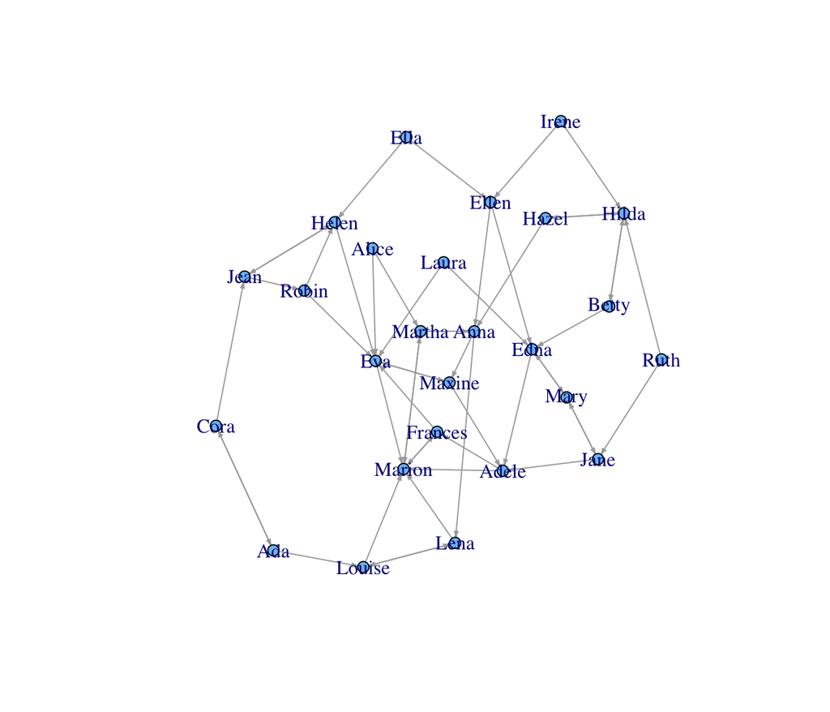

```r
# Plot network
# Adjust the edge arrow size for less ugliness
plot(dining, vertex.label=V(dining)$id, vertex.size = 5, edge.arrow.size= .25)
```

### Step 4: Calculate in-degree *(2 pts)*

Calculate in-degree for the nodes (`degree` function with `mode="in"`) and display a summary (`summary` function) of the in-degree data. (Hint: The mean should be 2 and the max should be 6.)

```r
# In-degree
degree.in = degree(dining, mode = 'in')
summary(degree.in)
```

```
##    Min. 1st Qu.  Median    Mean 3rd Qu.    Max.
##    0.00    1.00    2.00    2.00    2.75    6.00
```

### Step 5: Visualization 2 *(2 pts)*

Plot the in-degree distribution in a histogram. You can use either base plotting or ggplot to do this.

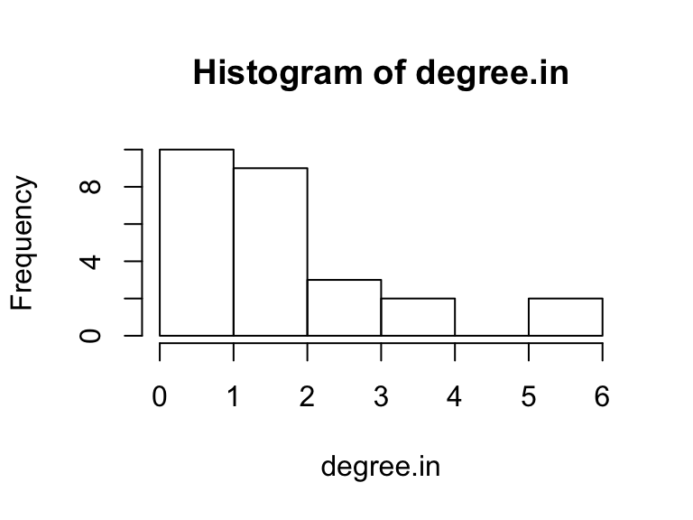

```r
# Degree distribution histogram
hist(degree.in)
```

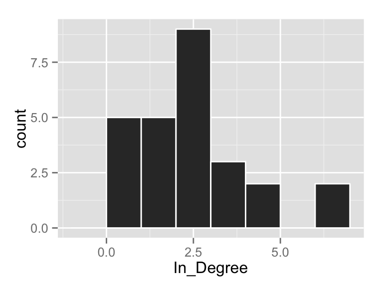

```r
# GGPlot version (optional)
g = ggplot(data.frame(In_Degree = degree.in), aes(x = In_Degree))
g = g + geom_histogram(binwidth = 1, col = "white")
print(g)
```

### Step 7: Computing edge weights *(1 pt)*

Next we will add appropriate edge weights to our calculations. There are weights on the edges, but they are the values 1 and 2, representing first and second choice. The value 1 should be a **stronger** tie and the value 2 a **weaker** one.

Create a new edge attribute `wt` that is 1 when the `weight` attribute is 1 and 0.5 when the `weight` attribute is 2. You can use `ifelse` or arithmetic calculation to do this.

```r
# Calculate wt attribute
E(dining)$weight
```

```
##  [1] 2 1 1 2 1 2 1 2 1 2 2 1 1 2 1 2 1 2 1 2 1 2 1 2 1 2 1 2 1 2 1 2 1 2 1
## [36] 2 1 2 1 2 1 2 1 2 1 2 1 2 1 2 1 2
```

```r
wt = E(dining)$weight
wt = ifelse(wt == 1,1,.5)
wt
```

```
##  [1] 0.5 1.0 1.0 0.5 1.0 0.5 1.0 0.5 1.0 0.5 0.5 1.0 1.0 0.5 1.0 0.5 1.0
## [18] 0.5 1.0 0.5 1.0 0.5 1.0 0.5 1.0 0.5 1.0 0.5 1.0 0.5 1.0 0.5 1.0 0.5
## [35] 1.0 0.5 1.0 0.5 1.0 0.5 1.0 0.5 1.0 0.5 1.0 0.5 1.0 0.5 1.0 0.5 1.0
## [52] 0.5
```

### Step 8: Compute weighted degree *(1 pt)*

The `graph.strength` function computes weighted degree values. Use this function to compute weighted in-degree using the `wt` attribute computed in Step 7.

(Hint: the summary should show a mean of 1.5 and a max of 5.)

```r
# Compute weighted degree
g.weighted = graph.strength(dining, vids = V(dining), mode = "in", weights = wt, loops = FALSE)
summary(g.weighted)
```

```
##    Min. 1st Qu.  Median    Mean 3rd Qu.    Max.
##   0.000   0.625   1.500   1.500   2.000   5.000
```

### Step 9: Visualization 4 *(2 pts)*

Weighted degree will be a real number, not an integer. Use a binwidth of 0.5 and make sure that the limits on X axis are correct.

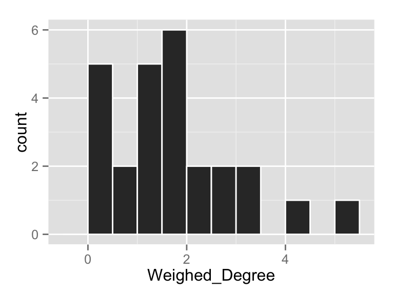

```r
# Visualization
g = ggplot(data.frame(Weighed_Degree = g.weighted), aes(x = Weighed_Degree))
g = g + geom_histogram(binwidth = .5, col = "white")
print(g)
```

### Extra credit: Weighted plot *(2 pts)*

Produce a graph plot in which the nodes are sized as a function of weighted in-degree. (Use the `size` parameter to the `plot` function.) The label should also be sized by weighted degree. (The `label.cex` parameter does this.) Edge width should be function of the edge weight, using the `edge.width` parameter.

Note that you are striving for readability in the visualization. Some nodes have in-degree of zero – it is not a good idea for these to have zero size vertices and labels. You will need to compute a function of the in-degree value to get appropriate sizes and this function will be different for node size and label size.

A sample visualization is included in the zip file for inspiration.

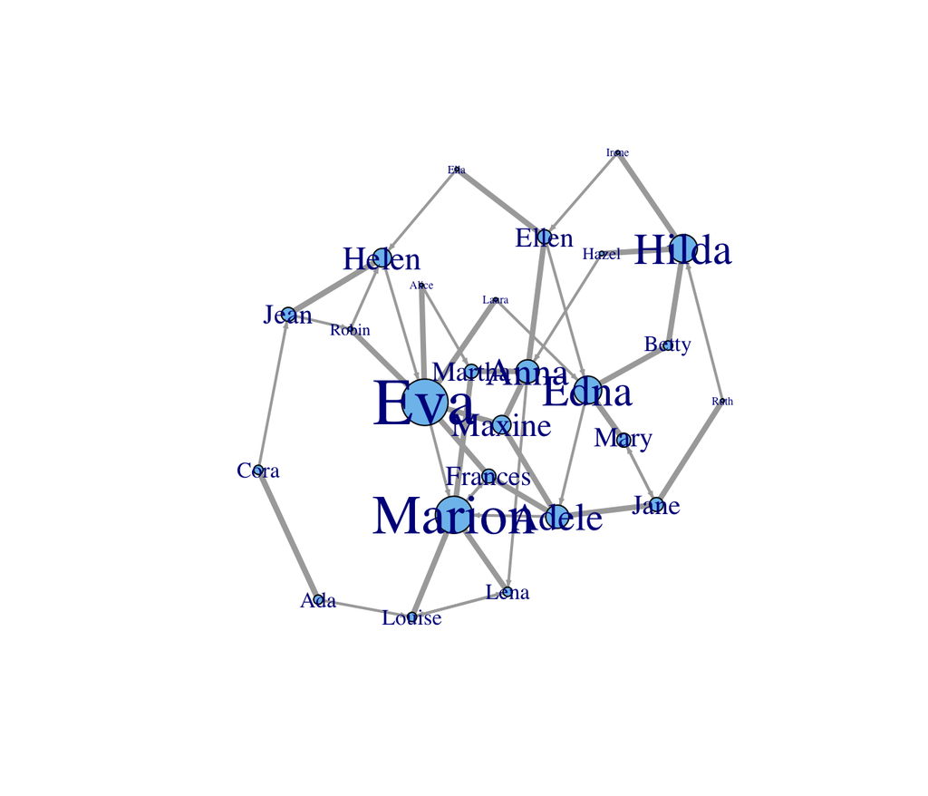

```r
# Visualization with weighted degree and weighted edges
# to get ride of 0s in weighted degree, I added 1
# the multiplication and division of weights is
# for visualization purposes.
V(dining)$label.cex = (g.weighted + 1) / 2
wt.viz = wt*4
g.vertex.weights = g.weighted * 4
plot(dining, vertex.label=V(dining)$id, vertex.size = g.vertex.weights, edge.arrow.size= .25, edge.width = wt.viz)
```